# Home work 11

Matti Kuikka 24.11.2023

##### NOTE: This Home work contains EXTRA tasks at the end where you are able to earn additional 5 points!

- Other Data Management skills you learned (where you can earn max 3 extra points)
- Data Management skills not covered in this course, but should have covered (for Introduction to Data Engineering AND/OR Introduction to AI, where you can earn extra 2 points)

## 1. Reading data with Pandas, data exploration and cleaning

Reading data with Pandas

- How to use Pandas to read data from different sources and formats, such as CSV, Excel, JSON, and HTML files.

Data exploration

- How to inspect and explore the data using various Pandas methods and attributes.

Data cleaning

- How to clean and modify the data using various Pandas methods and attributes.

```python
# Add Python libraries you need for data reading and exploration
#  - use import statements
```

```python
# import libraries.
import pandas as pd
import numpy as np
import matplotlib.pyplot as plt
from sklearn.model_selection import train_test_split
from sklearn.linear_model import LinearRegression
from sklearn.metrics import mean_squared_error
from sklearn.impute import SimpleImputer
from sklearn.preprocessing import OneHotEncoder
from sklearn.compose import ColumnTransformer
from sklearn.pipeline import Pipeline
```

```python
# Add in here example how you read CSV data and explore the contents
```

```python
# Read the data
import pandas as pd

df = pd.read_csv('Winter_sports.csv')

print(df.to_string())
```

```
                       Activity Type                 Date  Favorite                                   Title Distance  Calories        Time  Avg HR  Max HR Aerobic TE Avg Ski Cadence Max Ski Cadence Avg Speed Max Speed Total Ascent Total Descent Avg Stride Length Avg Vertical Ratio Avg Vertical Oscil…
0       Cross Country Classic Skiing  2023-04-02 10:24:27     False                Rusko Perinteinen hiihto     6,20   375.000    00:44:01     120     166        3,4              69             233       8,4      34,0           71            82              2,04                0,0                   …
1       Cross Country Classic Skiing  2023-04-01 13:02:48     False                Rusko Perinteinen hiihto     1,85   126.000    00:16:36     110     134        2,0              76             159       6,7      28,9           19            26              1,47                0,0                   …
2       Cross Country Classic Skiing  2023-03-12 14:29:10     False                Rusko Perinteinen hiihto     8,48   308.000    01:26:02      83     115        1,2              69             173       5,9      11,7           17            22              1,43                0,0                   …
3       Cross Country Classic Skiing  2023-03-12 10:30:27     False                Rusko Perinteinen hiihto    11,53   869.000    01:38:53     128     156        4,3              84             159       7,0      13,3           17            27              1,39                0,0                   …
4       Cross Country Classic Skiing  2023-03-11 13:06:16     False                Rusko Perinteinen hiihto    12,52   767.000    01:50:23     115     127        3,0              87             160       6,8      12,9           21            20              1,30                0,0                   …
5       Cross Country Classic Skiing  2023-03-09 17:18:26     False                Rusko Perinteinen hiihto     6,11   310.000    01:02:36      96     137        1,5              77             159       5,9      13,4           11            20              1,27                0,0                   …
6       Cross Country Classic Skiing  2023-03-04 15:45:24     False           Nousiainen Perinteinen hiihto     7,73   455.000    01:06:07     107     137        2,9              80             187       7,0      24,1           74            88              1,45                0,0                   …
7       Cross Country Classic Skiing  2023-02-26 17:51:06     False                Rusko Perinteinen hiihto     6,27   284.000    00:45:36     103     175        2,7              64             199       8,3      30,7           69            83              2,16                0,0                   …
8       Cross Country Classic Skiing  2023-02-24 11:07:04     False           Nousiainen Perinteinen hiihto     5,69   248.000    00:51:59      95     136        1,5              64             230       6,6      33,5          104           109              1,72                0,0                   …
9       Cross Country Classic Skiing  2023-02-21 10:35:42     False           Pudasjärvi Perinteinen hiihto    19,07   881.000    02:56:33     103     133        2,4              71             249       6,5      28,0          215           448              1,54                0,0                   …
10      Cross Country Classic Skiing  2023-02-20 10:14:07     False           Pudasjärvi Perinteinen hiihto    23,29     1.433    03:37:06     117     151        3,6              76             243       6,4      35,2          323           320              1,41                0,0                   …
11      Cross Country Classic Skiing  2023-02-19 15:55:12     False           Pudasjärvi Perinteinen hiihto     6,14   375.000    01:10:34     101     134        2,1              55             159       5,2      23,2           66            73              1,59                0,0                   …
12      Cross Country Classic Skiing  2022-03-05 10:50:14     False           Nousiainen Perinteinen hiihto     7,67   270.000    01:02:49      93     147        1,5              60             242       7,3      27,7           63            84              2,03                0,0                   …
13      Cross Country Classic Skiing  2022-02-27 11:32:30     False           Nousiainen Perinteinen hiihto    15,50   711.000    02:08:18     104     127        2,4              63             227       7,2      15,2           38            40              1,91                0,0                   …
```

[output cut: 121 more lines]

```python
# Display basic information about the DataFrame
print("Basic information about the DataFrame:")
print(df.info())

# Display the first few rows of the DataFrame
print("\nFirst few rows of the DataFrame:")
print(df.head())

# Display summary statistics of the DataFrame
print("\nSummary statistics of the DataFrame:")
print(df.describe())

# Display unique values in a specific column
print("\nUnique values in the 'Column_Name' column:")
print(df['Calories'].unique())

# Count the occurrences of each value in a specific column
print("\nValue counts in the 'Calories' column:")
print(df['Calories'].value_counts())
```

```
Basic information about the DataFrame:
<class 'pandas.core.frame.DataFrame'>
RangeIndex: 135 entries, 0 to 134
Data columns (total 39 columns):
 #   Column                    Non-Null Count  Dtype
---  ------                    --------------  -----
 0   Activity Type             135 non-null    object
 1   Date                      135 non-null    object
 2   Favorite                  135 non-null    bool
 3   Title                     135 non-null    object
 4   Distance                  135 non-null    object
 5   Calories                  135 non-null    float64
 6   Time                      135 non-null    object
 7   Avg HR                    135 non-null    int64
 8   Max HR                    135 non-null    int64
 9   Aerobic TE                135 non-null    object
 10  Avg Ski Cadence           135 non-null    object
 11  Max Ski Cadence           135 non-null    object
 12  Avg Speed                 135 non-null    object
 13  Max Speed                 135 non-null    object
 14  Total Ascent              135 non-null    object
 15  Total Descent             135 non-null    object
 16  Avg Stride Length         135 non-null    object
 17  Avg Vertical Ratio        135 non-null    object
 18  Avg Vertical Oscillation  135 non-null    object
 19  Avg Ground Contact Time   135 non-null    int64
 20  Training Stress Score®    135 non-null    object
 21  Avg Power                 135 non-null    int64
 22  Max Power                 135 non-null    int64
 23  Grit                      135 non-null    object
 24  Flow                      135 non-null    object
 25  Avg. Swolf                135 non-null    int64
 26  Avg Stroke Rate           135 non-null    int64
 27  Total Reps                135 non-null    int64
 28  Dive Time                 135 non-null    object
 29  Min Temp                  135 non-null    object
 30  Surface Interval          135 non-null    object
 31  Decompression             135 non-null    object
 32  Best Lap Time             135 non-null    object
 33  Number of Laps            135 non-null    object
```

[output cut: 82 more lines]

```
 798.    462.    781.    522.    630.    604.    622.    962.   ]

Value counts in the 'Calories' column:
375.0    3
172.0    2
119.0    2
695.0    2
209.0    2
        ..
74.0     1
364.0    1
205.0    1
144.0    1
962.0    1
Name: Calories, Length: 125, dtype: int64
```

```python
# Add in here example how you read JSON data and explore the contents
# - cover both files containing JSON and if pure JSON objects are read
```

```python
import pandas as pd
import json

# Example 1: Reading JSON from a file
json_file_path = 'path/to/your/data.json'  # Update this with the actual path to your JSON file

# Read JSON data from a file into a Pandas DataFrame
df_from_json_file = pd.read_json(json_file_path)

# Display basic information about the DataFrame
print("Basic information about the DataFrame (from JSON file):")
print(df_from_json_file.info())

# Display the first few rows of the DataFrame
print("\nFirst few rows of the DataFrame (from JSON file):")
print(df_from_json_file.head())

# Display summary statistics of the DataFrame
print("\nSummary statistics of the DataFrame (from JSON file):")
print(df_from_json_file.describe())

# Example 2: Reading JSON from a string
json_string = '{"name": "John", "age": 30, "city": "New York"}'  # Replace with your JSON-formatted string

# Convert the JSON string to a Python dictionary
json_data = json.loads(json_string)

# Create a DataFrame from the dictionary
df_from_json_string = pd.DataFrame.from_dict([json_data])

# Display basic information about the DataFrame
print("\nBasic information about the DataFrame (from JSON string):")
print(df_from_json_string.info())

# Display the DataFrame (from JSON string)
print("\nDataFrame from JSON string:")
print(df_from_json_string)
```

[output not shown]

```python
# Add in here examples how you clean data
# Data can be the CSV you have already read or it could be also Excel or HTML format data
```

```python
import pandas as pd

# Assuming df is your DataFrame loaded from a CSV file
# Replace 'Date' with the actual date column you want to clean

# Example: Cleaning and standardizing date format
df['Date'] = pd.to_datetime(df['Date'], errors='coerce')

# Handling missing dates
df['Date'].fillna(pd.to_datetime('today'), inplace=True)

# Display basic information after cleaning
print("Basic information about the DataFrame after cleaning:")
print(df.info())

# Display the first few rows after cleaning
print("\nFirst few rows of the DataFrame after cleaning:")
print(df.head())
```

[output not shown]

[output cut: 56 more lines]

## 2. Data formats

Converting data from one format to another using Pandas.

- you write the dataframes into different formats, such as CSV, Excel, JSON, and HTML files.

```python
# Add in here example how you convert data from JSON to CSV
```

```python
# Assuming you have a JSON file named data.json with the following structure:
[
    {"Name": "John", "Age": 30, "City": "New York"},
    {"Name": "Alice", "Age": 25, "City": "San Francisco"},
    {"Name": "Bob", "Age": 35, "City": "Los Angeles"}
]

import pandas as pd

# Load JSON data into a Pandas DataFrame
json_file_path = 'path/to/your/data.json'  # Update with the actual path to your JSON file
df = pd.read_json(json_file_path)

# Convert DataFrame to CSV
csv_file_path = 'path/to/your/data.csv'  # Specify the path for the CSV file
df.to_csv(csv_file_path, index=False)

print(f"Data successfully converted from JSON to CSV. CSV file saved at: {csv_file_path}")
```

[output not shown]

```python
# Add in here example how you can convert Pandas DataFrame column to other format
# - to numbers
# - to strings
```

```python
# Convert a Pandas DataFrame Column to Numbers:

import pandas as pd

# Create a sample DataFrame
data = {'Numbers': ['10', '20', '30', '40']}
df = pd.DataFrame(data)

# Convert the 'Numbers' column to numeric values
df['Numbers'] = pd.to_numeric(df['Numbers'])

# Display the DataFrame after conversion
print("DataFrame after converting 'Numbers' column to numbers:")
print(df)
```

```
DataFrame after converting 'Numbers' column to numbers:
   Numbers
0       10
1       20
2       30
3       40
```

```python
# Convert a Pandas DataFrame Column to Strings
import pandas as pd

# Create a sample DataFrame
data = {'Numbers': [10, 20, 30, 40]}
df = pd.DataFrame(data)

# Convert the 'Numbers' column to strings
df['Numbers'] = df['Numbers'].astype(str)

# Display the DataFrame after conversion
print("DataFrame after converting 'Numbers' column to strings:")
print(df)
```

```
DataFrame after converting 'Numbers' column to strings:
  Numbers
0      10
1      20
2      30
3      40
```

```python
# How you convert data incluing ','' as decimal sign to '.' as decimal sign? (Example: 3,25 -> 3.25)
```

```python
import pandas as pd

# Create a sample DataFrame with a column containing ',' as a decimal separator
data = {'DecimalColumn': ['3,25', '4,5', '6,75', '8,0']}
df = pd.DataFrame(data)

# Convert ',' to '.' and then convert the column to numeric
df['DecimalColumn'] = df['DecimalColumn'].str.replace(',', '.').astype(float)

# Display the DataFrame after conversion
print("DataFrame after converting ',' to '.' as a decimal separator:")
print(df)
```

```
DataFrame after converting ',' to '.' as a decimal separator:
   DecimalColumn
0           3.25
1           4.50
2           6.75
3           8.00
```

## 3. Data visualization

You can use Pandas, Matplotlib, and Seaborn to create various types of data visualizations, such as line plots, bar plots, scatter plots, histograms, box plots, and heatmaps.

You can also use various parameters and functions to modify the appearance and style of the plots, such as the labels, the titles, the legends, the colors and the grids.

```python
# Add Python libraries you need for data visualization
#  - use import statements
```

```python
import pandas as pd
import matplotlib.pyplot as plt
import seaborn as sns
```

```python
# Add in here example how you create graph (e.g. bar graph, boxplot or histogram) using Pandas
```

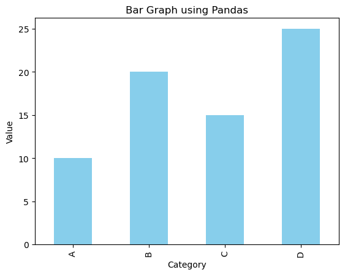

```python
import pandas as pd
import numpy as np

# Create a sample DataFrame
data = {'Category': ['A', 'B', 'C', 'D'],
        'Value': [10, 20, 15, 25]}
df = pd.DataFrame(data)

# Bar Graph using Pandas
df.plot(kind='bar', x='Category', y='Value', color='skyblue', legend=False)
plt.title('Bar Graph using Pandas')
plt.xlabel('Category')
plt.ylabel('Value')
plt.show()
```

```python
# Add in here example how you create graph (e.g. bar graph, boxplot or histogram) using Matplotlib
```

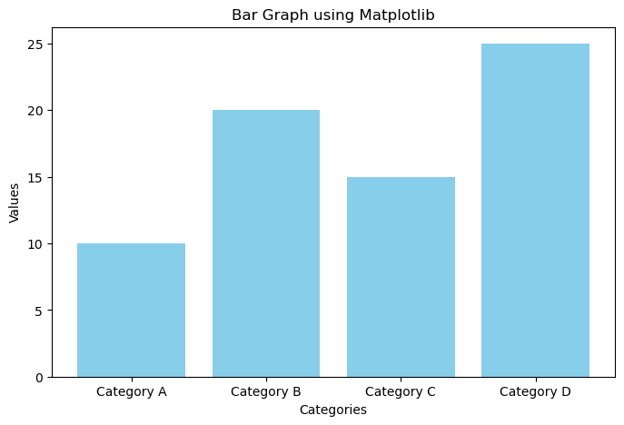

```python
import matplotlib.pyplot as plt

# Sample data
categories = ['Category A', 'Category B', 'Category C', 'Category D']
values = [10, 20, 15, 25]

# Create a bar graph using Matplotlib
plt.figure(figsize=(8, 5))
plt.bar(categories, values, color='skyblue')
plt.title('Bar Graph using Matplotlib')
plt.xlabel('Categories')
plt.ylabel('Values')
plt.show()
```

```python
# Add in here example how you create graph (e.g. scatter diagram, bar graph, boxplot or histogram) using Seaborn
```

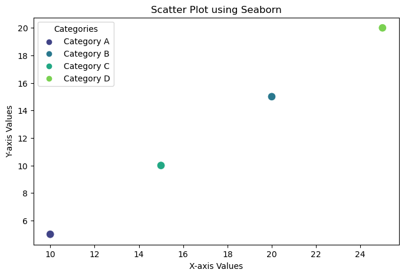

```python
import seaborn as sns
import matplotlib.pyplot as plt

# Sample data
categories = ['Category A', 'Category B', 'Category C', 'Category D']
values_x = [10, 20, 15, 25]
values_y = [5, 15, 10, 20]

# Create a scatter plot using Seaborn
plt.figure(figsize=(8, 5))
sns.scatterplot(x=values_x, y=values_y, hue=categories, palette='viridis', s=100)
plt.title('Scatter Plot using Seaborn')
plt.xlabel('X-axis Values')
plt.ylabel('Y-axis Values')
plt.legend(title='Categories', loc='upper left')
plt.show()
```

```python
# Add in here example how you change the layout of figures using Matplotlib
```

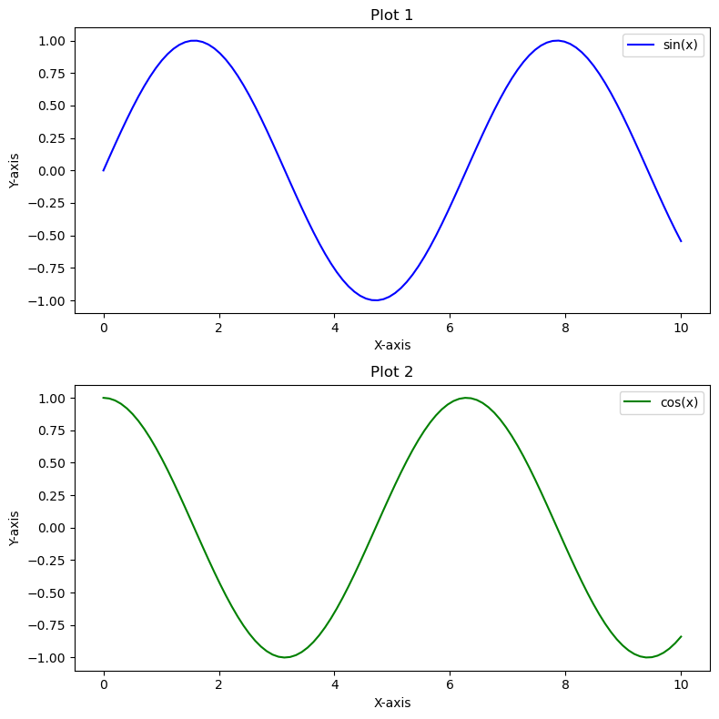

```python
import matplotlib.pyplot as plt
import numpy as np

# Sample data
x = np.linspace(0, 10, 100)
y1 = np.sin(x)
y2 = np.cos(x)

# Create a 2x1 grid of subplots
fig, axs = plt.subplots(2, 1, figsize=(8, 8))

# Plot on the first subplot
axs[0].plot(x, y1, color='blue', label='sin(x)')
axs[0].set_title('Plot 1')
axs[0].set_xlabel('X-axis')
axs[0].set_ylabel('Y-axis')
axs[0].legend()

# Plot on the second subplot
axs[1].plot(x, y2, color='green', label='cos(x)')
axs[1].set_title('Plot 2')
axs[1].set_xlabel('X-axis')
axs[1].set_ylabel('Y-axis')
axs[1].legend()

# Adjust layout to prevent clipping of titles
plt.tight_layout()

# Show the plots
plt.show()
```